# Risk Factor Analysis

## Outcome Variable

**Outcome Variable:** pers_wast

## Predictor Variables

**Intervention Variable:** nchldlt5

**Adjustment Set:**

- arm
- W_mage
- meducyrs
- feducyrs
- hhwealth_quart
- hfoodsec
- W_mhtcm
- W_nrooms
- W_parity
- impfloor
- impsan
- safeh20
- delta_W_mage
- delta_meducyrs
- delta_feducyrs
- delta_hhwealth_quart
- delta_hfoodsec
- delta_W_mhtcm
- delta_W_nrooms
- delta_W_parity
- delta_impfloor
- delta_impsan
- delta_safeh20

## Stratifying Variables

The analysis was stratified on these variable(s):

- agecat
- studyid
- country

## Data Summary

| agecat | studyid | country | nchldlt5 | pers_wast | n_cell | n |
| --- | --- | --- | --- | --- | --- | --- |
| 0-24 months | ki1000108-IRC | INDIA | 1 | 0 | 79 | 410 |
| 0-24 months | ki1000108-IRC | INDIA | 1 | 1 | 10 | 410 |
| 0-24 months | ki1000108-IRC | INDIA | 2+ | 0 | 283 | 410 |
| 0-24 months | ki1000108-IRC | INDIA | 2+ | 1 | 38 | 410 |
| 0-24 months | ki1017093b-PROVIDE | BANGLADESH | 1 | 0 | 459 | 640 |
| 0-24 months | ki1017093b-PROVIDE | BANGLADESH | 1 | 1 | 10 | 640 |
| 0-24 months | ki1017093b-PROVIDE | BANGLADESH | 2+ | 0 | 166 | 640 |
| 0-24 months | ki1017093b-PROVIDE | BANGLADESH | 2+ | 1 | 5 | 640 |
| 0-24 months | ki1017093c-NIH-Crypto | BANGLADESH | 1 | 0 | 504 | 730 |
| 0-24 months | ki1017093c-NIH-Crypto | BANGLADESH | 1 | 1 | 16 | 730 |
| 0-24 months | ki1017093c-NIH-Crypto | BANGLADESH | 2+ | 0 | 200 | 730 |
| 0-24 months | ki1017093c-NIH-Crypto | BANGLADESH | 2+ | 1 | 10 | 730 |
| 0-24 months | ki1066203-TanzaniaChild2 | TANZANIA, UNITED REPUBLIC OF | 1 | 0 | 1440 | 2157 |
| 0-24 months | ki1066203-TanzaniaChild2 | TANZANIA, UNITED REPUBLIC OF | 1 | 1 | 38 | 2157 |
| 0-24 months | ki1066203-TanzaniaChild2 | TANZANIA, UNITED REPUBLIC OF | 2+ | 0 | 659 | 2157 |
| 0-24 months | ki1066203-TanzaniaChild2 | TANZANIA, UNITED REPUBLIC OF | 2+ | 1 | 20 | 2157 |
| 0-24 months | ki1112895-iLiNS-Zinc | BURKINA FASO | 1 | 0 | 488 | 1639 |
| 0-24 months | ki1112895-iLiNS-Zinc | BURKINA FASO | 1 | 1 | 62 | 1639 |
| 0-24 months | ki1112895-iLiNS-Zinc | BURKINA FASO | 2+ | 0 | 958 | 1639 |
| 0-24 months | ki1112895-iLiNS-Zinc | BURKINA FASO | 2+ | 1 | 131 | 1639 |
| 0-24 months | ki1148112-LCNI-5 | MALAWI | 1 | 0 | 337 | 711 |
| 0-24 months | ki1148112-LCNI-5 | MALAWI | 1 | 1 | 4 | 711 |
| 0-24 months | ki1148112-LCNI-5 | MALAWI | 2+ | 0 | 368 | 711 |
| 0-24 months | ki1148112-LCNI-5 | MALAWI | 2+ | 1 | 2 | 711 |
| 0-24 months | kiGH5241-JiVitA-3 | BANGLADESH | 1 | 0 | 9461 | 15669 |
| 0-24 months | kiGH5241-JiVitA-3 | BANGLADESH | 1 | 1 | 596 | 15669 |
| 0-24 months | kiGH5241-JiVitA-3 | BANGLADESH | 2+ | 0 | 5311 | 15669 |
| 0-24 months | kiGH5241-JiVitA-3 | BANGLADESH | 2+ | 1 | 301 | 15669 |
| 0-6 months | ki1000108-IRC | INDIA | 1 | 0 | 69 | 402 |
| 0-6 months | ki1000108-IRC | INDIA | 1 | 1 | 16 | 402 |
| 0-6 months | ki1000108-IRC | INDIA | 2+ | 0 | 269 | 402 |
| 0-6 months | ki1000108-IRC | INDIA | 2+ | 1 | 48 | 402 |
| 0-6 months | ki1017093b-PROVIDE | BANGLADESH | 1 | 0 | 458 | 637 |
| 0-6 months | ki1017093b-PROVIDE | BANGLADESH | 1 | 1 | 9 | 637 |
| 0-6 months | ki1017093b-PROVIDE | BANGLADESH | 2+ | 0 | 165 | 637 |
| 0-6 months | ki1017093b-PROVIDE | BANGLADESH | 2+ | 1 | 5 | 637 |
| 0-6 months | ki1017093c-NIH-Crypto | BANGLADESH | 1 | 0 | 193 | 250 |
| 0-6 months | ki1017093c-NIH-Crypto | BANGLADESH | 1 | 1 | 4 | 250 |
| 0-6 months | ki1017093c-NIH-Crypto | BANGLADESH | 2+ | 0 | 52 | 250 |
| 0-6 months | ki1017093c-NIH-Crypto | BANGLADESH | 2+ | 1 | 1 | 250 |
| 0-6 months | ki1066203-TanzaniaChild2 | TANZANIA, UNITED REPUBLIC OF | 1 | 0 | 1372 | 2053 |
| 0-6 months | ki1066203-TanzaniaChild2 | TANZANIA, UNITED REPUBLIC OF | 1 | 1 | 36 | 2053 |
| 0-6 months | ki1066203-TanzaniaChild2 | TANZANIA, UNITED REPUBLIC OF | 2+ | 0 | 629 | 2053 |
| 0-6 months | ki1066203-TanzaniaChild2 | TANZANIA, UNITED REPUBLIC OF | 2+ | 1 | 16 | 2053 |
| 0-6 months | kiGH5241-JiVitA-3 | BANGLADESH | 1 | 0 | 28 | 46 |
| 0-6 months | kiGH5241-JiVitA-3 | BANGLADESH | 1 | 1 | 1 | 46 |
| 0-6 months | kiGH5241-JiVitA-3 | BANGLADESH | 2+ | 0 | 16 | 46 |
| 0-6 months | kiGH5241-JiVitA-3 | BANGLADESH | 2+ | 1 | 1 | 46 |
| 6-24 months | ki1000108-IRC | INDIA | 1 | 0 | 79 | 410 |
| 6-24 months | ki1000108-IRC | INDIA | 1 | 1 | 10 | 410 |
| 6-24 months | ki1000108-IRC | INDIA | 2+ | 0 | 283 | 410 |
| 6-24 months | ki1000108-IRC | INDIA | 2+ | 1 | 38 | 410 |
| 6-24 months | ki1017093b-PROVIDE | BANGLADESH | 1 | 0 | 459 | 640 |
| 6-24 months | ki1017093b-PROVIDE | BANGLADESH | 1 | 1 | 10 | 640 |
| 6-24 months | ki1017093b-PROVIDE | BANGLADESH | 2+ | 0 | 166 | 640 |
| 6-24 months | ki1017093b-PROVIDE | BANGLADESH | 2+ | 1 | 5 | 640 |
| 6-24 months | ki1017093c-NIH-Crypto | BANGLADESH | 1 | 0 | 504 | 730 |
| 6-24 months | ki1017093c-NIH-Crypto | BANGLADESH | 1 | 1 | 16 | 730 |
| 6-24 months | ki1017093c-NIH-Crypto | BANGLADESH | 2+ | 0 | 200 | 730 |
| 6-24 months | ki1017093c-NIH-Crypto | BANGLADESH | 2+ | 1 | 10 | 730 |
| 6-24 months | ki1066203-TanzaniaChild2 | TANZANIA, UNITED REPUBLIC OF | 1 | 0 | 1440 | 2157 |
| 6-24 months | ki1066203-TanzaniaChild2 | TANZANIA, UNITED REPUBLIC OF | 1 | 1 | 38 | 2157 |
| 6-24 months | ki1066203-TanzaniaChild2 | TANZANIA, UNITED REPUBLIC OF | 2+ | 0 | 659 | 2157 |
| 6-24 months | ki1066203-TanzaniaChild2 | TANZANIA, UNITED REPUBLIC OF | 2+ | 1 | 20 | 2157 |
| 6-24 months | ki1112895-iLiNS-Zinc | BURKINA FASO | 1 | 0 | 488 | 1639 |
| 6-24 months | ki1112895-iLiNS-Zinc | BURKINA FASO | 1 | 1 | 62 | 1639 |
| 6-24 months | ki1112895-iLiNS-Zinc | BURKINA FASO | 2+ | 0 | 958 | 1639 |
| 6-24 months | ki1112895-iLiNS-Zinc | BURKINA FASO | 2+ | 1 | 131 | 1639 |
| 6-24 months | ki1148112-LCNI-5 | MALAWI | 1 | 0 | 337 | 711 |
| 6-24 months | ki1148112-LCNI-5 | MALAWI | 1 | 1 | 4 | 711 |
| 6-24 months | ki1148112-LCNI-5 | MALAWI | 2+ | 0 | 368 | 711 |
| 6-24 months | ki1148112-LCNI-5 | MALAWI | 2+ | 1 | 2 | 711 |
| 6-24 months | kiGH5241-JiVitA-3 | BANGLADESH | 1 | 0 | 9461 | 15669 |
| 6-24 months | kiGH5241-JiVitA-3 | BANGLADESH | 1 | 1 | 596 | 15669 |
| 6-24 months | kiGH5241-JiVitA-3 | BANGLADESH | 2+ | 0 | 5311 | 15669 |
| 6-24 months | kiGH5241-JiVitA-3 | BANGLADESH | 2+ | 1 | 301 | 15669 |

The following strata were considered:

- agecat: 0-24 months, studyid: ki1000108-IRC, country: INDIA
- agecat: 0-24 months, studyid: ki1017093b-PROVIDE, country: BANGLADESH
- agecat: 0-24 months, studyid: ki1017093c-NIH-Crypto, country: BANGLADESH
- agecat: 0-24 months, studyid: ki1066203-TanzaniaChild2, country: TANZANIA, UNITED REPUBLIC OF
- agecat: 0-24 months, studyid: ki1112895-iLiNS-Zinc, country: BURKINA FASO
- agecat: 0-24 months, studyid: ki1148112-LCNI-5, country: MALAWI
- agecat: 0-24 months, studyid: kiGH5241-JiVitA-3, country: BANGLADESH
- agecat: 0-6 months, studyid: ki1000108-IRC, country: INDIA
- agecat: 0-6 months, studyid: ki1017093b-PROVIDE, country: BANGLADESH
- agecat: 0-6 months, studyid: ki1017093c-NIH-Crypto, country: BANGLADESH
- agecat: 0-6 months, studyid: ki1066203-TanzaniaChild2, country: TANZANIA, UNITED REPUBLIC OF
- agecat: 0-6 months, studyid: kiGH5241-JiVitA-3, country: BANGLADESH
- agecat: 6-24 months, studyid: ki1000108-IRC, country: INDIA
- agecat: 6-24 months, studyid: ki1017093b-PROVIDE, country: BANGLADESH
- agecat: 6-24 months, studyid: ki1017093c-NIH-Crypto, country: BANGLADESH
- agecat: 6-24 months, studyid: ki1066203-TanzaniaChild2, country: TANZANIA, UNITED REPUBLIC OF
- agecat: 6-24 months, studyid: ki1112895-iLiNS-Zinc, country: BURKINA FASO
- agecat: 6-24 months, studyid: ki1148112-LCNI-5, country: MALAWI
- agecat: 6-24 months, studyid: kiGH5241-JiVitA-3, country: BANGLADESH

### Dropped Strata

Some strata were dropped due to rare outcomes:

- agecat: 0-24 months, studyid: ki1148112-LCNI-5, country: MALAWI
- agecat: 0-6 months, studyid: ki1017093c-NIH-Crypto, country: BANGLADESH
- agecat: 0-6 months, studyid: kiGH5241-JiVitA-3, country: BANGLADESH
- agecat: 6-24 months, studyid: ki1148112-LCNI-5, country: MALAWI

## Methods Detail

We’re interested in the causal parameters $E[Y_a]$ for all values of $a \in \mathcal{A}$. These parameters represent the mean outcome if, possibly contrary to fact, we intervened to set all units to have $A=a$. Under the randomization and positivity assumptions, these are identified by the statistical parameters $\psi_a=E_W[E_{Y|A,W}(Y|A=a,W)]$. In addition, we’re interested in the mean of $Y$, $E[Y]$ under no intervention (the observed mean). We will estimate these parameters by using SuperLearner to fit the relevant likelihood factors – $E_{Y|A,W}(Y|A=a,W)$ and $p(A=a|W)$, and then updating our likelihood fit using a joint TMLE.

For unadjusted analyses ($W=\{\}$), initial likelihoods were estimated using Lrnr_glm to estimate the simple $E(Y|A)$ and Lrnr_mean to estimate $p(A)$. For adjusted analyses, a small library containing Lrnr_glmnet, Lrnr_xgboost, and Lrnr_mean was used.

Having estimated these parameters, we will then use the delta method to estimate relative risks and attributable risks relative to a prespecified baseline level of $A$.

# Results Detail

## Results Plots

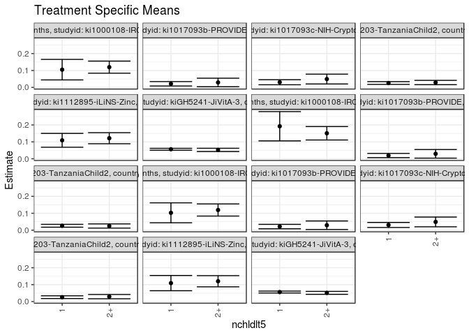

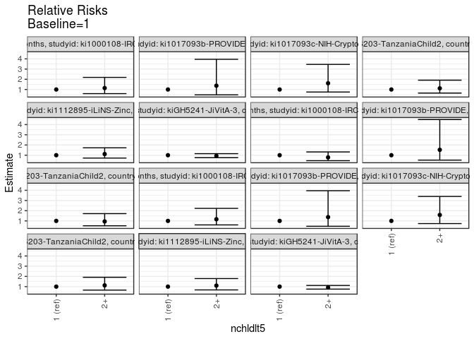

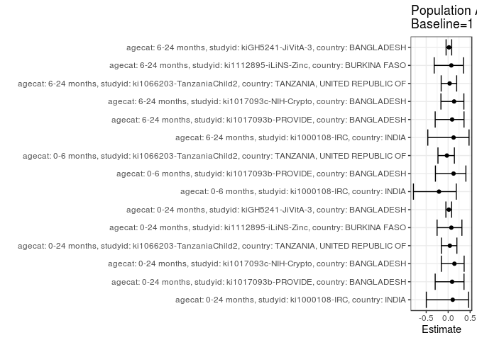

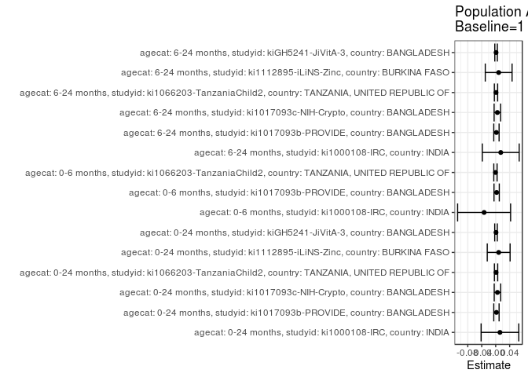

## Results Table

### Parameter: TSM

| agecat | studyid | country | intervention_level | baseline_level | estimate | ci_lower | ci_upper |
| --- | --- | --- | --- | --- | --- | --- | --- |
| 0-24 months | ki1000108-IRC | INDIA | 1 | NA | 0.1048938 | 0.0442981 | 0.1654895 |
| 0-24 months | ki1000108-IRC | INDIA | 2+ | NA | 0.1197482 | 0.0839402 | 0.1555561 |
| 0-24 months | ki1017093b-PROVIDE | BANGLADESH | 1 | NA | 0.0213220 | 0.0082381 | 0.0344058 |
| 0-24 months | ki1017093b-PROVIDE | BANGLADESH | 2+ | NA | 0.0292398 | 0.0039682 | 0.0545114 |
| 0-24 months | ki1017093c-NIH-Crypto | BANGLADESH | 1 | NA | 0.0305411 | 0.0157355 | 0.0453466 |
| 0-24 months | ki1017093c-NIH-Crypto | BANGLADESH | 2+ | NA | 0.0492561 | 0.0202256 | 0.0782865 |
| 0-24 months | ki1066203-TanzaniaChild2 | TANZANIA, UNITED REPUBLIC OF | 1 | NA | 0.0258589 | 0.0177902 | 0.0339276 |
| 0-24 months | ki1066203-TanzaniaChild2 | TANZANIA, UNITED REPUBLIC OF | 2+ | NA | 0.0288180 | 0.0160958 | 0.0415402 |
| 0-24 months | ki1112895-iLiNS-Zinc | BURKINA FASO | 1 | NA | 0.1091949 | 0.0682391 | 0.1501506 |
| 0-24 months | ki1112895-iLiNS-Zinc | BURKINA FASO | 2+ | NA | 0.1215946 | 0.0888324 | 0.1543568 |
| 0-24 months | kiGH5241-JiVitA-3 | BANGLADESH | 1 | NA | 0.0563443 | 0.0506564 | 0.0620322 |
| 0-24 months | kiGH5241-JiVitA-3 | BANGLADESH | 2+ | NA | 0.0525703 | 0.0428659 | 0.0622746 |
| 0-6 months | ki1000108-IRC | INDIA | 1 | NA | 0.1923848 | 0.1058622 | 0.2789075 |
| 0-6 months | ki1000108-IRC | INDIA | 2+ | NA | 0.1508970 | 0.1112547 | 0.1905392 |
| 0-6 months | ki1017093b-PROVIDE | BANGLADESH | 1 | NA | 0.0192719 | 0.0067933 | 0.0317506 |
| 0-6 months | ki1017093b-PROVIDE | BANGLADESH | 2+ | NA | 0.0294118 | 0.0039937 | 0.0548299 |
| 0-6 months | ki1066203-TanzaniaChild2 | TANZANIA, UNITED REPUBLIC OF | 1 | NA | 0.0260471 | 0.0176289 | 0.0344654 |
| 0-6 months | ki1066203-TanzaniaChild2 | TANZANIA, UNITED REPUBLIC OF | 2+ | NA | 0.0246471 | 0.0123359 | 0.0369583 |
| 6-24 months | ki1000108-IRC | INDIA | 1 | NA | 0.1025617 | 0.0435509 | 0.1615724 |
| 6-24 months | ki1000108-IRC | INDIA | 2+ | NA | 0.1194378 | 0.0835965 | 0.1552791 |
| 6-24 months | ki1017093b-PROVIDE | BANGLADESH | 1 | NA | 0.0213220 | 0.0082381 | 0.0344058 |
| 6-24 months | ki1017093b-PROVIDE | BANGLADESH | 2+ | NA | 0.0292398 | 0.0039682 | 0.0545114 |
| 6-24 months | ki1017093c-NIH-Crypto | BANGLADESH | 1 | NA | 0.0307925 | 0.0159258 | 0.0456592 |
| 6-24 months | ki1017093c-NIH-Crypto | BANGLADESH | 2+ | NA | 0.0487657 | 0.0199423 | 0.0775890 |
| 6-24 months | ki1066203-TanzaniaChild2 | TANZANIA, UNITED REPUBLIC OF | 1 | NA | 0.0259826 | 0.0179115 | 0.0340538 |
| 6-24 months | ki1066203-TanzaniaChild2 | TANZANIA, UNITED REPUBLIC OF | 2+ | NA | 0.0291958 | 0.0165179 | 0.0418738 |
| 6-24 months | ki1112895-iLiNS-Zinc | BURKINA FASO | 1 | NA | 0.1092252 | 0.0642564 | 0.1541940 |
| 6-24 months | ki1112895-iLiNS-Zinc | BURKINA FASO | 2+ | NA | 0.1202114 | 0.0872409 | 0.1531818 |
| 6-24 months | kiGH5241-JiVitA-3 | BANGLADESH | 1 | NA | 0.0561653 | 0.0505131 | 0.0618176 |
| 6-24 months | kiGH5241-JiVitA-3 | BANGLADESH | 2+ | NA | 0.0515961 | 0.0429566 | 0.0602356 |

### Parameter: E(Y)

| agecat | studyid | country | intervention_level | baseline_level | estimate | ci_lower | ci_upper |
| --- | --- | --- | --- | --- | --- | --- | --- |
| 0-24 months | ki1000108-IRC | INDIA | NA | NA | 0.1170732 | 0.0859146 | 0.1482317 |
| 0-24 months | ki1017093b-PROVIDE | BANGLADESH | NA | NA | 0.0234375 | 0.0117074 | 0.0351676 |
| 0-24 months | ki1017093c-NIH-Crypto | BANGLADESH | NA | NA | 0.0356164 | 0.0221630 | 0.0490699 |
| 0-24 months | ki1066203-TanzaniaChild2 | TANZANIA, UNITED REPUBLIC OF | NA | NA | 0.0268892 | 0.0200612 | 0.0337172 |
| 0-24 months | ki1112895-iLiNS-Zinc | BURKINA FASO | NA | NA | 0.1177547 | 0.0931926 | 0.1423168 |
| 0-24 months | kiGH5241-JiVitA-3 | BANGLADESH | NA | NA | 0.0572468 | 0.0531533 | 0.0613403 |
| 0-6 months | ki1000108-IRC | INDIA | NA | NA | 0.1592040 | 0.1233945 | 0.1950135 |
| 0-6 months | ki1017093b-PROVIDE | BANGLADESH | NA | NA | 0.0219780 | 0.0105837 | 0.0333723 |
| 0-6 months | ki1066203-TanzaniaChild2 | TANZANIA, UNITED REPUBLIC OF | NA | NA | 0.0253288 | 0.0185306 | 0.0321270 |
| 6-24 months | ki1000108-IRC | INDIA | NA | NA | 0.1170732 | 0.0859146 | 0.1482317 |
| 6-24 months | ki1017093b-PROVIDE | BANGLADESH | NA | NA | 0.0234375 | 0.0117074 | 0.0351676 |
| 6-24 months | ki1017093c-NIH-Crypto | BANGLADESH | NA | NA | 0.0356164 | 0.0221630 | 0.0490699 |
| 6-24 months | ki1066203-TanzaniaChild2 | TANZANIA, UNITED REPUBLIC OF | NA | NA | 0.0268892 | 0.0200612 | 0.0337172 |
| 6-24 months | ki1112895-iLiNS-Zinc | BURKINA FASO | NA | NA | 0.1177547 | 0.0931926 | 0.1423168 |
| 6-24 months | kiGH5241-JiVitA-3 | BANGLADESH | NA | NA | 0.0572468 | 0.0531533 | 0.0613403 |

### Parameter: RR

| agecat | studyid | country | intervention_level | baseline_level | estimate | ci_lower | ci_upper |
| --- | --- | --- | --- | --- | --- | --- | --- |
| 0-24 months | ki1000108-IRC | INDIA | 1 | 1 | 1.0000000 | 1.0000000 | 1.000000 |
| 0-24 months | ki1000108-IRC | INDIA | 2+ | 1 | 1.1416136 | 0.5956391 | 2.188039 |
| 0-24 months | ki1017093b-PROVIDE | BANGLADESH | 1 | 1 | 1.0000000 | 1.0000000 | 1.000000 |
| 0-24 months | ki1017093b-PROVIDE | BANGLADESH | 2+ | 1 | 1.3713450 | 0.4751244 | 3.958094 |
| 0-24 months | ki1017093c-NIH-Crypto | BANGLADESH | 1 | 1 | 1.0000000 | 1.0000000 | 1.000000 |
| 0-24 months | ki1017093c-NIH-Crypto | BANGLADESH | 2+ | 1 | 1.6127819 | 0.7517614 | 3.459961 |
| 0-24 months | ki1066203-TanzaniaChild2 | TANZANIA, UNITED REPUBLIC OF | 1 | 1 | 1.0000000 | 1.0000000 | 1.000000 |
| 0-24 months | ki1066203-TanzaniaChild2 | TANZANIA, UNITED REPUBLIC OF | 2+ | 1 | 1.1144345 | 0.6492626 | 1.912884 |
| 0-24 months | ki1112895-iLiNS-Zinc | BURKINA FASO | 1 | 1 | 1.0000000 | 1.0000000 | 1.000000 |
| 0-24 months | ki1112895-iLiNS-Zinc | BURKINA FASO | 2+ | 1 | 1.1135563 | 0.7191351 | 1.724304 |
| 0-24 months | kiGH5241-JiVitA-3 | BANGLADESH | 1 | 1 | 1.0000000 | 1.0000000 | 1.000000 |
| 0-24 months | kiGH5241-JiVitA-3 | BANGLADESH | 2+ | 1 | 0.9330183 | 0.7566279 | 1.150530 |
| 0-6 months | ki1000108-IRC | INDIA | 1 | 1 | 1.0000000 | 1.0000000 | 1.000000 |
| 0-6 months | ki1000108-IRC | INDIA | 2+ | 1 | 0.7843495 | 0.4658705 | 1.320548 |
| 0-6 months | ki1017093b-PROVIDE | BANGLADESH | 1 | 1 | 1.0000000 | 1.0000000 | 1.000000 |
| 0-6 months | ki1017093b-PROVIDE | BANGLADESH | 2+ | 1 | 1.5261438 | 0.5183367 | 4.493440 |
| 0-6 months | ki1066203-TanzaniaChild2 | TANZANIA, UNITED REPUBLIC OF | 1 | 1 | 1.0000000 | 1.0000000 | 1.000000 |
| 0-6 months | ki1066203-TanzaniaChild2 | TANZANIA, UNITED REPUBLIC OF | 2+ | 1 | 0.9462495 | 0.5220489 | 1.715142 |
| 6-24 months | ki1000108-IRC | INDIA | 1 | 1 | 1.0000000 | 1.0000000 | 1.000000 |
| 6-24 months | ki1000108-IRC | INDIA | 2+ | 1 | 1.1645461 | 0.6086375 | 2.228203 |
| 6-24 months | ki1017093b-PROVIDE | BANGLADESH | 1 | 1 | 1.0000000 | 1.0000000 | 1.000000 |
| 6-24 months | ki1017093b-PROVIDE | BANGLADESH | 2+ | 1 | 1.3713450 | 0.4751244 | 3.958094 |
| 6-24 months | ki1017093c-NIH-Crypto | BANGLADESH | 1 | 1 | 1.0000000 | 1.0000000 | 1.000000 |
| 6-24 months | ki1017093c-NIH-Crypto | BANGLADESH | 2+ | 1 | 1.5836848 | 0.7386511 | 3.395457 |
| 6-24 months | ki1066203-TanzaniaChild2 | TANZANIA, UNITED REPUBLIC OF | 1 | 1 | 1.0000000 | 1.0000000 | 1.000000 |
| 6-24 months | ki1066203-TanzaniaChild2 | TANZANIA, UNITED REPUBLIC OF | 2+ | 1 | 1.1236667 | 0.6593428 | 1.914978 |
| 6-24 months | ki1112895-iLiNS-Zinc | BURKINA FASO | 1 | 1 | 1.0000000 | 1.0000000 | 1.000000 |
| 6-24 months | ki1112895-iLiNS-Zinc | BURKINA FASO | 2+ | 1 | 1.1005827 | 0.6773651 | 1.788226 |
| 6-24 months | kiGH5241-JiVitA-3 | BANGLADESH | 1 | 1 | 1.0000000 | 1.0000000 | 1.000000 |
| 6-24 months | kiGH5241-JiVitA-3 | BANGLADESH | 2+ | 1 | 0.9186468 | 0.7565461 | 1.115480 |

### Parameter: PAR

| agecat | studyid | country | intervention_level | baseline_level | estimate | ci_lower | ci_upper |
| --- | --- | --- | --- | --- | --- | --- | --- |
| 0-24 months | ki1000108-IRC | INDIA | 1 | NA | 0.0121794 | -0.0418266 | 0.0661854 |
| 0-24 months | ki1017093b-PROVIDE | BANGLADESH | 1 | NA | 0.0021155 | -0.0054928 | 0.0097239 |
| 0-24 months | ki1017093c-NIH-Crypto | BANGLADESH | 1 | NA | 0.0050754 | -0.0042304 | 0.0143812 |
| 0-24 months | ki1066203-TanzaniaChild2 | TANZANIA, UNITED REPUBLIC OF | 1 | NA | 0.0010303 | -0.0037077 | 0.0057683 |
| 0-24 months | ki1112895-iLiNS-Zinc | BURKINA FASO | 1 | NA | 0.0085599 | -0.0241983 | 0.0413180 |
| 0-24 months | kiGH5241-JiVitA-3 | BANGLADESH | 1 | NA | 0.0009025 | -0.0028165 | 0.0046215 |
| 0-6 months | ki1000108-IRC | INDIA | 1 | NA | -0.0331809 | -0.1090884 | 0.0427267 |
| 0-6 months | ki1017093b-PROVIDE | BANGLADESH | 1 | NA | 0.0027061 | -0.0048588 | 0.0102710 |
| 0-6 months | ki1066203-TanzaniaChild2 | TANZANIA, UNITED REPUBLIC OF | 1 | NA | -0.0007184 | -0.0054313 | 0.0039946 |
| 6-24 months | ki1000108-IRC | INDIA | 1 | NA | 0.0145115 | -0.0382984 | 0.0673214 |
| 6-24 months | ki1017093b-PROVIDE | BANGLADESH | 1 | NA | 0.0021155 | -0.0054928 | 0.0097239 |
| 6-24 months | ki1017093c-NIH-Crypto | BANGLADESH | 1 | NA | 0.0048239 | -0.0045088 | 0.0141566 |
| 6-24 months | ki1066203-TanzaniaChild2 | TANZANIA, UNITED REPUBLIC OF | 1 | NA | 0.0009066 | -0.0038262 | 0.0056393 |
| 6-24 months | ki1112895-iLiNS-Zinc | BURKINA FASO | 1 | NA | 0.0085295 | -0.0298810 | 0.0469401 |
| 6-24 months | kiGH5241-JiVitA-3 | BANGLADESH | 1 | NA | 0.0010815 | -0.0025702 | 0.0047331 |

### Parameter: PAF

| agecat | studyid | country | intervention_level | baseline_level | estimate | ci_lower | ci_upper |
| --- | --- | --- | --- | --- | --- | --- | --- |
| 0-24 months | ki1000108-IRC | INDIA | 1 | NA | 0.1040321 | -0.4977426 | 0.4640211 |
| 0-24 months | ki1017093b-PROVIDE | BANGLADESH | 1 | NA | 0.0902630 | -0.2955223 | 0.3611677 |
| 0-24 months | ki1017093c-NIH-Crypto | BANGLADESH | 1 | NA | 0.1425011 | -0.1563222 | 0.3641008 |
| 0-24 months | ki1066203-TanzaniaChild2 | TANZANIA, UNITED REPUBLIC OF | 1 | NA | 0.0383173 | -0.1546696 | 0.1990491 |
| 0-24 months | ki1112895-iLiNS-Zinc | BURKINA FASO | 1 | NA | 0.0726924 | -0.2523006 | 0.3133443 |
| 0-24 months | kiGH5241-JiVitA-3 | BANGLADESH | 1 | NA | 0.0157650 | -0.0514722 | 0.0787026 |
| 0-6 months | ki1000108-IRC | INDIA | 1 | NA | -0.2084173 | -0.7907316 | 0.1845387 |
| 0-6 months | ki1017093b-PROVIDE | BANGLADESH | 1 | NA | 0.1231263 | -0.2899494 | 0.4039244 |
| 0-6 months | ki1066203-TanzaniaChild2 | TANZANIA, UNITED REPUBLIC OF | 1 | NA | -0.0283613 | -0.2321700 | 0.1417361 |
| 6-24 months | ki1000108-IRC | INDIA | 1 | NA | 0.1239524 | -0.4634149 | 0.4755695 |
| 6-24 months | ki1017093b-PROVIDE | BANGLADESH | 1 | NA | 0.0902630 | -0.2955223 | 0.3611677 |
| 6-24 months | ki1017093c-NIH-Crypto | BANGLADESH | 1 | NA | 0.1354407 | -0.1643748 | 0.3580566 |
| 6-24 months | ki1066203-TanzaniaChild2 | TANZANIA, UNITED REPUBLIC OF | 1 | NA | 0.0337147 | -0.1589765 | 0.1943691 |
| 6-24 months | ki1112895-iLiNS-Zinc | BURKINA FASO | 1 | NA | 0.0724347 | -0.3183239 | 0.3473703 |
| 6-24 months | kiGH5241-JiVitA-3 | BANGLADESH | 1 | NA | 0.0188912 | -0.0471209 | 0.0807418 |